# Benchmarking detection of DNA copy number variation using high-density methylation microarrays

# Code Paper for Benchmarking Project

Hi! This is a very informally written document just to give the beats of what is happening in the code, and the analysis I am doing. It needs to be MUCH more formalized before being shown publicly, but it is useful for understanding!

## Preprocessing

All data is in disparate forms. So, I standardized it so that it can be easily utilized in the downstream without having to continuously redo work. I chose to standardize the notation to the Conumee notations, using

- chrom for chromosomes.
- loc.start for when the location of a segment starts.
- loc.end for when the location of a segment ends.
- seg.mean for the log2-ratio.
- CNVStatus for whether a block represents a deletion, amplification & normal segments.
- type is a representative factor to say what method gave that segment, because we compose a database for each case, and we need to distinguish the segments from each other.
- we also add an extra factor named “Gene” to label relevant segments which have a gene inside it.

Attached are the pre-processing blocks.

#### LMS Processing

```r
labLMSProc <- function(STTq, Technology, binSize) {

    # Correlate by STT information between methylation
    # Sentrix and SNP data.
    correlationSheet <- read.csv("~/Work/Analysis/LabData/LMS_SNP_EPIC_array_data/correlative.csv") %>%
        filter(STT == STTq)

    cnvMatch <- read_delim(paste0("~/Work/Analysis/LabData/LMS_SNP_EPIC_array_data/ChAS/ChAS_data_01Feb2026/ChAS_LMS_Probe_and_segment_level_data_01Feb2026/STT",
        STTq, "_Recentered_Segment_level_data_01Feb2026.segment.txt"))

    # methylMatch <-
    # read.csv(paste0('~/Work/Analysis/Outputs/MethylMaster/LabLMS/',
    # paste0(correlationSheet$Sentrix_ID[1],'_',
    # correlationSheet$Sentrix_Position[1], '/'),
    # 'autocorrected_regions.csv'))

    conumeeMatch <- read.csv(paste0("~/Work/Analysis/Outputs/Conumee/LabLMS/",
        binSize, "/", paste0(correlationSheet$Sentrix_ID[1],
            "_", correlationSheet$Sentrix_Position[1], ".csv")))

    sesameMatch <- read.csv(paste0("~/Work/Analysis/Outputs/SeSAMe/LabLMS/",
        binSize, "/", paste0("segments_", correlationSheet$Sentrix_ID[1],
            "_", correlationSheet$Sentrix_Position[1], ".csv")))

    methylMatch <- read.csv(paste0("~/Work/Analysis/Outputs/MethylMaster/LabLMS/",
        binSize, "/", correlationSheet$Sentrix_ID[1], "_", correlationSheet$Sentrix_Position[1],
        "/autocorrected_regions.csv"))

    cnvMatch <- cnvMatch %>%
        dplyr::filter(!(Type == "LOH")) %>%
        dplyr::filter(Chromosome != 24 & Chromosome != 25) %>%
        dplyr::select("Chromosome", "StartPosition", "StopPosition",
            "Median Log2 Ratio") %>%
        dplyr::rename(chrom = "Chromosome", loc.start = "StartPosition",
            loc.end = "StopPosition", seg.mean = "Median Log2 Ratio") %>%
        dplyr::mutate(seg.mean = as.numeric(seg.mean)) %>%
        dplyr::mutate(CNVStatus = case_when(seg.mean <= -0.2 ~
            "Deletion", seg.mean >= 0.2 ~ "Amplification", TRUE ~
            "Normal"), type = "SNP")

    if (Technology == "MethylMaster") {
        methylMatch <- methylMatch %>%
            dplyr::rename(seg.mean = "Mean", loc.start = "bp.Start",
                loc.end = "bp.End") %>%
            dplyr::select(seg.mean, loc.start, loc.end, Chromosome) %>%
            mutate(type = "MethylMaster") %>%
            dplyr::rename(chrom = "Chromosome") %>%
            dplyr::mutate(chrom = as.numeric(gsub("chr", "",
                chrom))) %>%
            filter(!is.na(chrom)) %>%
            dplyr::mutate(loc.start = as.numeric(loc.start),
                loc.end = as.numeric(loc.end), seg.mean = as.numeric(seg.mean)) %>%
            mutate(CNVStatus = case_when(seg.mean <= -0.2 ~ "Deletion",
                seg.mean >= 0.2 ~ "Amplification", TRUE ~ "Normal"))
        combinedSet <- rbind(methylMatch, cnvMatch) %>%
            mutate(Gene = as.character(0)) %>%
            arrange(chrom)
    }

    if (Technology == "Conumee") {
        conumeeMatch <- conumeeMatch %>%
            dplyr::select(chrom, loc.start, loc.end, seg.mean) %>%
            mutate(CNVStatus = case_when(seg.mean <= -0.2 ~ "Deletion",
                seg.mean >= 0.2 ~ "Amplification", TRUE ~ "Normal")) %>%
            mutate(chrom = as.numeric(gsub("chr", "", chrom))) %>%
            mutate(type = "Conumee")
        combinedSet <- rbind(conumeeMatch, cnvMatch) %>%
            mutate(Gene = as.character(0)) %>%
            arrange(chrom)
    }

    if (Technology == "Sesame") {
        sesameMatch <- sesameMatch %>%
            dplyr::select(c("chrom", "loc.start", "loc.end",
                "seg.mean")) %>%
            dplyr::mutate(chrom = str_remove_all(chrom, "chr")) %>%
            filter(!(chrom == "X") & !(chrom == "Y")) %>%
            mutate(chrom = as.numeric(chrom)) %>%
            arrange(chrom) %>%
            mutate(CNVStatus = case_when(seg.mean > 0.3 ~ "Amplification",
                seg.mean < -0.3 ~ "Deletion", TRUE ~ "Normal"),
                type = "SeSAMe")
        combinedSet <- rbind(sesameMatch, cnvMatch) %>%
            mutate(Gene = as.character(0), seg.mean = as.numeric(seg.mean)) %>%
            arrange(chrom)
    }
    combinedSet
}
```

It utilizes an unique identifier (STT) to retrieve relevant datasets from inside the files and processes them into the correct format. It then returns the whole dataset.

#### LM Processing

```r
LMStt <- function(STT, bin) {

    corrSheet <- read.csv("~/Work/Analysis/LabData/LM_SNP_EPIC_array_data/EPIC_array_data_LM/idat_files/SampSheet.csv") %>%
        dplyr::filter(STT == STT)
    sentrixID <- corrSheet$Sentrix_ID[1]
    sentrixPos <- corrSheet$Sentrix_Position[1]

    SNP <- read_delim(paste0("~/Work/Analysis/LabData/LM_SNP_EPIC_array_data/ChAS/ChAS_data_01Feb2026/ChAS_LM_Probe_and_segment_level_data_01Feb2026/STT",
        STT, "_Segment_level_data_01Feb2026.segment.txt"))
    SNP <- SNP %>%
        dplyr::filter(!(Type == "LOH")) %>%
        dplyr::filter(Chromosome != 24 & Chromosome != 25) %>%
        dplyr::select("Chromosome", "StartPosition", "StopPosition",
            "Median Log2 Ratio") %>%
        dplyr::rename(chrom = "Chromosome", loc.start = "StartPosition",
            loc.end = "StopPosition", seg.mean = "Median Log2 Ratio") %>%
        dplyr::mutate(seg.mean = as.numeric(seg.mean)) %>%
        dplyr::mutate(CNVStatus = case_when(seg.mean <= -0.2 ~
            "Deletion", seg.mean >= 0.2 ~ "Amplification", TRUE ~
            "Normal"), type = "SNP")

    # MethylMasteR
    outputDirMethyl <- paste0("~/Work/Analysis/Outputs/MethylMaster/LM/",
        bin, "/", sentrixID, "_", sentrixPos, "/autocorrected_regions.csv")
    cnvMethyl <- read.csv(outputDirMethyl) %>%
        dplyr::select(c("Chromosome", "bp.Start", "bp.End", "Mean")) %>%
        dplyr::rename(chrom = "Chromosome", loc.start = "bp.Start",
            loc.end = "bp.End", seg.mean = "Mean") %>%
        dplyr::mutate(CNVStatus = case_when(seg.mean > 0.3 ~
            "Amplification", seg.mean < -0.3 ~ "Deletion", TRUE ~
            "Normal"), type = "MethylMaster")
    cnvMethyl$chrom <- as.numeric(str_remove_all(cnvMethyl$chrom,
        pattern = "chr"))
    cnvMethyl <- cnvMethyl %>%
        filter(!(is.na(chrom))) %>%
        arrange(chrom)

    # SeSAMe
    outputDirSesame <- paste0("~/Work/Analysis/Outputs/SeSAMe/LM/bins/",
        bin, "/", "segments_", sentrixID, "_", sentrixPos, ".csv")
    sesameOutput <- read.csv(outputDirSesame) %>%
        dplyr::select(c("chrom", "loc.start", "loc.end", "seg.mean")) %>%
        dplyr::mutate(chrom = str_remove_all(chrom, "chr")) %>%
        filter(!(chrom == "X") & !(chrom == "Y")) %>%
        mutate(chrom = as.numeric(chrom)) %>%
        arrange(chrom) %>%
        mutate(CNVStatus = case_when(seg.mean > 0.3 ~ "Amplification",
            seg.mean < -0.3 ~ "Deletion", TRUE ~ "Normal"), type = "SeSAMe")

    # Conumee
    outputDirConumee <- paste0("~/Work/Analysis/Outputs/Conumee/LMData/bins/",
        bin, "/", sentrixID, "_", sentrixPos, ".csv")
    case <- read.csv(outputDirConumee)
    case <- case %>%
        dplyr::select(-c("ID", "bstat")) %>%
        mutate(CNVStatus = case_when(case$seg.mean > 0.2 ~ "Amplification",
            case$seg.mean < -0.2 ~ "Deletion", TRUE ~ "Normal"),
            chrom = as.numeric(str_remove_all(chrom, "chr"))) %>%
        dplyr::arrange(chrom) %>%
        mutate(type = "Conumee") %>%
        dplyr::select(-c("num.mark", "pval", "seg.median", "X"))

    rbind(SNP, case, sesameOutput, cnvMethyl)

}
```

This does basically the same thing, except for leiomyoma samples instead of leiomyosarcoma samples. It then returns the relevant dataset. The Gene factor is dropped because it is not evaluated for Leiomyoma.

#### Normal Processing

```r
labNmrlProc <- function(Sentrix, Technology, binSize) {
    # Correlate by STT information between methylation
    # Sentrix and SNP data.
    correlationSheet <- read.csv("~/Work/Analysis/LabData/Normal_smooth_muscle_EPIC_data/idat_files/Sample_Sheet_Normal.csv") %>%
        filter(Basename == Sentrix)

    conumeeMatch <- read.csv(paste0("~/Work/Analysis/Outputs/Conumee/LabNormals/",
        binSize, "/", paste0(Sentrix, ".csv")))

    sesameMatch <- read.csv(paste0("~/Work/Analysis/Outputs/SeSAMe/Normals/",
        binSize, "/", paste0("segments_", Sentrix, ".csv")))

    if (Technology == "MethylMaster") {
        methylMatch <- methylMatch %>%
            dplyr::rename(seg.mean = "Mean", loc.start = "bp.Start",
                loc.end = "bp.End") %>%
            dplyr::select(seg.mean, loc.start, loc.end, Chromosome) %>%
            mutate(type = "MethylMaster") %>%
            dplyr::rename(chrom = "Chromosome") %>%
            dplyr::mutate(chrom = as.numeric(gsub("chr", "",
                chrom))) %>%
            filter(!is.na(chrom)) %>%
            dplyr::mutate(loc.start = as.numeric(loc.start),
                loc.end = as.numeric(loc.end), seg.mean = as.numeric(seg.mean)) %>%
            mutate(CNVStatus = case_when(seg.mean <= -0.2 ~ "Deletion",
                seg.mean >= 0.2 ~ "Amplification", TRUE ~ "Normal"))
        combinedSet <- methylMatch %>%
            arrange(chrom)
    }

    if (Technology == "Conumee") {
        conumeeMatch <- conumeeMatch %>%
            dplyr::select(chrom, loc.start, loc.end, seg.mean) %>%
            mutate(CNVStatus = case_when(seg.mean <= -0.2 ~ "Deletion",
                seg.mean >= 0.2 ~ "Amplification", TRUE ~ "Normal")) %>%
            mutate(chrom = as.numeric(gsub("chr", "", chrom))) %>%
            mutate(type = "Conumee")
        combinedSet <- conumeeMatch %>%
            arrange(chrom)
    }

    if (Technology == "Sesame") {
        sesameMatch <- sesameMatch %>%
            dplyr::select(c("chrom", "loc.start", "loc.end",
                "seg.mean")) %>%
            dplyr::mutate(chrom = str_remove_all(chrom, "chr")) %>%
            filter(!(chrom == "X") & !(chrom == "Y")) %>%
            mutate(chrom = as.numeric(chrom)) %>%
            arrange(chrom) %>%
            mutate(CNVStatus = case_when(seg.mean > 0.3 ~ "Amplification",
                seg.mean < -0.3 ~ "Deletion", TRUE ~ "Normal"),
                type = "SeSAMe")
        combinedSet <- sesameMatch %>%
            arrange(chrom)
    }

    combinedSet
}
```

This is the final processing function to process out the normals, contributing to the genome-wide log2-ratio.

## Analysis

**We now move onto the actual meat of the analytic code. This will be split into statistics generation & visualization.**

### Basic Metrics

#### Bin size vs. accuracy – normal tissue

This was done to evaluate whether the tissues that were being used for normalization were actually normal. The code has been annotated with comments below to gain full understanding of the system.

This entire evaluation is contained in a function, which asks for a set of IDs (essentially the IDs of the normals, and the bin that we want to evaluate the statistics for.

```r
caseCorr <- function(IDs, bin) {

    Methyl <- c()
    Ses <- c()
    Con <- c()

    for (ID in IDs) {
        MethylMaster <- read.csv(paste0("~/Outputs/MethylMaster/Normals/",
            bin, "/", ID, "/autocorrected_regions.csv"))
        MethylMaster <- median(MethylMaster$Mean)
        Sesame <- read.csv(paste0("~/Outputs/SeSAMe/Normals/",
            bin, "/segments_", ID, ".csv"))
        Sesame <- median(Sesame$seg.mean)
        Conumee <- read.csv(paste0("~/Outputs/Conumee/LabNormals/",
            bin, "/", ID, ".csv"))
        Conumee <- median(Conumee$seg.mean)

        Methyl <- c(Methyl, MethylMaster)
        Ses <- c(Ses, Sesame)
        Con <- c(Con, Conumee)

    }

    acc <- data.frame(Conumee_Median = median(Con), Conumee_SD = sd(Con),
        Sesame_Median = median(Ses), Sesame_SD = sd(Ses), Methyl_Median = median(Methyl),
        Methyl_SD = sd(Methyl))
    acc

}
```

It then takes the median log2 ratio of each sample for each software and bin, and returns it as a list, given by the initialized Methyl (MethylMasteR), Ses (SeSAMe) and Con (Conumee) values.

It then returns a data frame for easy post-processing.

#### Genomic Index for LMS

```r
GenomicIndex <- function(dfCH3, sw) {
    if (sw == F) {
        dfSNP <- dfCH3 %>%
            dplyr::filter(type == "SNP") %>%
            dplyr::filter(CNVStatus != "Normal")
        modChrom <- length(unique(dfSNP$chrom))
        CNVCount <- nrow(dfSNP)
        ret <- (CNVCount^2)/modChrom
        return(ret)
    } else {

        # Filter out for clinically significant segments
        # %>% filter(CNVStatus != Normal)
        dfCH3f <- dfCH3 %>%
            dplyr::filter(type == "Conumee" | type == "MethylMaster" |
                type == "SeSAMe") %>%
            dplyr::filter(CNVStatus != "Normal")
        # Count
        CNVCount <- nrow(dfCH3f)
        modChrom <- length(unique(dfCH3f$chrom))

        # Return value
        ret <- (CNVCount^2)/modChrom
        return(ret)
    }
}
```

As given. It just then returns that value.

“sw” as an argument in the function is because I wanted to use the function for both SNPs and the methylation CNVs, so it is a convenient way to work with both types without using more if-statements.

#### Genome Modified

This is a pretty basic metric which works very similarly to the GI calculation above.

```r
GenomeModified <- function(dfCH3) {
    df <- dfCH3 %>%
        dplyr::filter(type != "SNP", CNVStatus != "Normal") %>%
        dplyr::mutate(width = loc.end - loc.start)
    modifiedWidth <- sum(df$width)
    hg19_info <- getChromInfoFromUCSC("hg19") %>%
        dplyr::filter(assembled == "TRUE")
    hg19_info <- hg19_info[1:22, ]
    hg19_total <- sum(hg19_info$size)

    return((modifiedWidth/hg19_total) * 100)

}
```

The driver code is quite important here however. It calculates the genome changed for each case, then adds it to an array. We can guarantee the order pair because the loop happens in the same order as the dataframe of the SNP data and how the cases are ordered in there.

Then, it prints out by taking a Pearson’s correlation on the different arrays, and in place, makes dataframes containing the percentage of genome changed, so that it can be manually inspected.

```r
stts <- c(9202, 9203, 9327, 9328, 9337, 9338, 9350, 9353, 9354,
    9355, 9356, 9357, 9358)
bins <- c(10000, 50000, 1e+05, 1e+06)
tech <- c("MethylMaster", "Conumee", "Sesame")
genomeCalc <- read_excel("~/Work/Analysis/LabData/LMS_SNP_EPIC_array_data/ChAS/ChAS_data_01Feb2026/design_13LMS_CNVs_other_info_01Feb2026.xlsx") %>%
    dplyr::select("STT", "% Genome Changed") %>%
    dplyr::rename(gc = "% Genome Changed")
bin10kb <- genomeCalc
binDef <- genomeCalc
bin100kb <- genomeCalc
bin1Mb <- genomeCalc

for (bin in bins) {
    print(bin)
    valM <- c()
    valS <- c()
    valC <- c()
    for (stt in stts) {
        valM <- c(valM, GenomeModified(labLMSProc(STTq = stt,
            Technology = "MethylMaster", binSize = bin)))
        valS <- c(valS, GenomeModified(labLMSProc(STTq = stt,
            Technology = "Sesame", binSize = bin)))
        valC <- c(valC, GenomeModified(labLMSProc(STTq = stt,
            Technology = "Conumee", binSize = bin)))
    }
    if (bin == 10000) {
        bin10kb <- data.frame(STT = bin10kb$STT, gc = bin10kb$gc,
            pcentmodM = valM, pcentmodS = valS, pcentmodC = valC)
    }
    if (bin == 50000) {
        binDef <- data.frame(STT = binDef$STT, gc = binDef$gc,
            pcentmodM = valM, pcentmodS = valS, pcentmodC = valC)
    }
    if (bin == 1e+05) {
        bin100kb <- data.frame(STT = bin100kb$STT, gc = bin100kb$gc,
            pcentmodM = valM, pcentmodS = valS, pcentmodC = valC)
    }
    if (bin == 1e+06) {
        bin1Mb <- data.frame(STT = bin1Mb$STT, gc = bin1Mb$gc,
            pcentmodM = valM, pcentmodS = valS, pcentmodC = valC)
    }

    print(paste0("MethylMasteR: ", cor(genomeCalc$gc, valM)))
    print(paste0("SeSAMe: ", cor(genomeCalc$gc, valS)))
    print(paste0("Conumee: ", cor(genomeCalc$gc, valC)))

}
```

```
## [1] 10000
```

```
## [1] "MethylMasteR: 0.687649075571811"
## [1] "SeSAMe: 0.00278326955354341"
## [1] "Conumee: -0.400415556914374"
## [1] 50000
```

```
## [1] "MethylMasteR: 0.755074036591727"
## [1] "SeSAMe: -0.0217828755036478"
## [1] "Conumee: -0.511121929626427"
## [1] 1e+05
```

```
## [1] "MethylMasteR: 0.754376210845057"
## [1] "SeSAMe: 0.0390561094591397"
## [1] "Conumee: -0.477686025489507"
## [1] 1e+06
```

```
## [1] "MethylMasteR: 0.740706152419858"
## [1] "SeSAMe: 0.0605428007233103"
## [1] "Conumee: -0.443940764266878"
```

### Advanced Metrics

#### Accuracy Across Bins

```r
fpCheck <- function(df) {
    library(GenomicRanges)
    library(dplyr)
    df <- df %>%
        dplyr::select(-c("Gene"))  # Removes genes, it's unnecessary for this purpose

    pred_df <- df %>%
        filter(!(type == "SNP"))  # The methylation dataset
    pred_df$chrom <- as.character(pred_df$chrom)
    truth_df <- df %>%
        filter(type == "SNP")  # The SNP dataset
    truth_df$chrom <- as.character(truth_df$chrom)

    # Both chromosomes are made into characters because we
    # want to use them as factors ---- Step 1: hg19
    # chromosome sizes (numeric chromosomes 1 to 22) ----
    hg19_info <- getChromInfoFromUCSC("hg19") %>%
        dplyr::filter(assembled == "TRUE")  # Just gets the main dataset from UCSC.
    hg19_info <- hg19_info[1:22, ]  # Only uses the first 22 chromosomes.
    hg19_chr_sizes <- data.frame(Chromosome = as.character(1:22),
        Genome_bp = hg19_info$size)  # Makes them into a referenceable dataframe.

    # ---- Step 2: Convert to GRanges ---- Does what it
    # says on the tin
    truth_gr <- GRanges(seqnames = truth_df$chrom, ranges = IRanges(start = truth_df$loc.start,
        end = truth_df$loc.end), CNV = truth_df$CNVStatus)

    pred_gr <- GRanges(seqnames = pred_df$chrom, ranges = IRanges(start = pred_df$loc.start,
        end = pred_df$loc.end), CNV = pred_df$CNVStatus)

    # ---- Step 3: Overlaps and TP ----
    hits <- findOverlaps(pred_gr, truth_gr)  # Finds the overlaps between the two GRanges

    overlap_ranges <- pintersect(pred_gr[queryHits(hits)], truth_gr[subjectHits(hits)])
    pred_cnv <- mcols(pred_gr)$CNV[queryHits(hits)]  # Returns whether the intersections are deletions, amplifications or normals
    truth_cnv <- mcols(truth_gr)$CNV[subjectHits(hits)]  # Returns whether the intersections are deletions, amplifications or normals

    # The returns are for the corresponding datasets.

    tp_df <- data.frame(Chromosome = as.character(seqnames(overlap_ranges)),
        width = width(overlap_ranges), pred_cnv = pred_cnv, truth_cnv = truth_cnv)  # Creates a dataframe from the given data
    tp_df <- tp_df %>%
        filter(pred_cnv == truth_cnv) %>%
        group_by(Chromosome) %>%
        summarise(TP_bp = sum(width), .groups = "drop")

    # ---- Step 4: False Positives ----
    fp_df <- data.frame(Chromosome = as.character(seqnames(overlap_ranges)),
        width = width(overlap_ranges), pred_cnv = pred_cnv, truth_cnv = truth_cnv) %>%
        filter(pred_cnv != truth_cnv, truth_cnv == "Normal") %>%
        group_by(Chromosome) %>%
        summarise(FP_bp = sum(width), .groups = "drop")  # Calculates the false positives

    # ---- Step 5: False Negatives ----
    fn_df <- data.frame(Chromosome = as.character(seqnames(overlap_ranges)),
        width = width(overlap_ranges), pred_cnv = pred_cnv, truth_cnv = truth_cnv) %>%
        filter(pred_cnv != truth_cnv, pred_cnv == "Normal") %>%
        group_by(Chromosome) %>%
        summarise(FN_bp = sum(width), .groups = "drop")  # Calculates the false negatives

    # ---- Step 6: Merge and compute accuracy ----
    final_eval <- hg19_chr_sizes %>%
        left_join(tp_df, by = "Chromosome") %>%
        left_join(fp_df, by = "Chromosome") %>%
        left_join(fn_df, by = "Chromosome") %>%
        mutate(across(c(TP_bp, FP_bp, FN_bp), ~replace_na(.,
            0))) %>%
        mutate(CNV_bp = TP_bp + FP_bp + FN_bp, TN_bp = Genome_bp -
            CNV_bp, Accuracy = (TP_bp + TN_bp)/Genome_bp, CNV_Only_Accuracy = ifelse((TP_bp +
            FP_bp + FN_bp) == 0, NA, TP_bp/(TP_bp + FP_bp + FN_bp))) %>%
        arrange(as.numeric(Chromosome))  # Joins all the analysis together, so it can be seen at once, and then calculates the accuracy across each case

    accuracy <- sum(final_eval$Accuracy)/22

    return(list(final_eval, accuracy))
}
```

This takes the processed dataframes from above, and checks against all possibilities, true negatives, true positives, and their false counterparts. It has been commented appropriately for understanding, as they all interact with each other.

#### **Gene level analysis**

This happens by:

- Annotating the genes initially with the Entrez gene database
- It then puts both of them into GRanges to intersect the two to make sure that we don’t call segments that aren’t a part of the genes we are studying
- It then annotates the segments with their relevant genes.
- It can happen that sometimes genes are split across two software-generated segments or SNP segments. In these cases, we take the average of the segments.

```r
NoGraphGeneGen <- function(Gene, db = NULL, case) {
    # Updated function.

    # This section annotates the processed dataframe with
    # genes by Querying Entrez to get the genes we want to,
    # get their locations Overlap those locations onto the
    # existing dataframe, and voila We know where the genes
    # are!
    entrez_idsDB <- mapIds(org.Hs.eg.db, keys = Gene, column = "ENTREZID",
        keytype = "SYMBOL", multiVals = "first")
    chr_locations <- AnnotationDbi::select(org.Hs.eg.db, keys = entrez_idsDB,
        columns = c("CHR", "CHRLOC", "CHRLOCEND"), keytype = "ENTREZID")
    txdb <- TxDb.Hsapiens.UCSC.hg19.knownGene
    gene_ranges <- genes(txdb)
    target_genes_ranges <- gene_ranges[gene_ranges$gene_id %in%
        entrez_idsDB]
    coords_df <- as.data.frame(target_genes_ranges)
    coords_df$entrez_id <- target_genes_ranges$gene_id
    coords_final <- coords_df[, c("entrez_id", "seqnames", "start",
        "end", "strand", "width")] %>%
        dplyr::mutate(chrom = seqnames) %>%
        dplyr::mutate(chrom = as.numeric(gsub("chr", "", chrom)),
            Gene = Gene) %>%
        dplyr::select(-c(seqnames))
    rownames(coords_final) <- Gene

    if (!is.null(db)) {
        print("is here")
        dt <- db %>%
            dplyr::filter((Gene == "0")) %>%
            dplyr::mutate(Gene = NA)  # We make sure we don't hold onto anything that
        # is not associated with a gene

        gcoords <- coords_final %>%
            dplyr::mutate(loc.start = as.numeric(start), loc.end = as.numeric(end)) %>%
            dplyr::mutate(seg.mean = 0, CNVStatus = "Normal",
                type = "Gene") %>%
            dplyr::mutate(Gene = Gene) %>%
            dplyr::select(-c("strand", "width", "entrez_id",
                "start", "end"))

        grC <- makeGRangesFromDataFrame(gcoords, start.field = "loc.start",
            end.field = "loc.end", keep.extra.columns = TRUE)
        grDt <- makeGRangesFromDataFrame(dt, start.field = "loc.start",
            end.field = "loc.end", keep.extra.columns = TRUE)

        overlaps <- findOverlaps(grDt, grC)

        # Extract intersection and bind gene annotation
        # immediately before any row changes
        intersection_df <- as.data.frame(pintersect(grDt[queryHits(overlaps)],
            grC[subjectHits(overlaps)])) %>%
            dplyr::select(-c("strand", "width", "hit", "Gene")) %>%
            dplyr::rename(loc.start = start, loc.end = end) %>%
            dplyr::mutate(chrom = as.numeric(seqnames)) %>%
            dplyr::select(-c("seqnames"))

        gene_annotations <- coords_final[subjectHits(overlaps),
            "Gene", drop = FALSE]
        overlapping_regions <- cbind(intersection_df, Gene = gene_annotations$Gene)

        # Find genes with no overlap for each type
        all_types <- unique(dt$type)
        missing_rows <- list()

        for (t in all_types) {
            # Detects if the gene is split between two or
            # more segments by taking the average instead
            dt_type <- dt %>%
                dplyr::filter(type == t)
            grDt_type <- makeGRangesFromDataFrame(dt_type, start.field = "loc.start",
                end.field = "loc.end", keep.extra.columns = TRUE)
            matched_genes <- unique(overlapping_regions$Gene[overlapping_regions$type ==
                t])
            missing_genes <- setdiff(rownames(coords_final),
                matched_genes)

            for (g in missing_genes) {
                gene_row <- coords_final[g, ]
                gene_mid <- (gene_row$start + gene_row$end)/2

                # Find flanking segments on same chromosome
                dt_chr <- dt_type %>%
                  dplyr::filter(chrom == gene_row$chrom)

                if (nrow(dt_chr) == 0)
                  next

                # Left flank: segments ending before gene
                # midpoint
                left <- dt_chr %>%
                  dplyr::filter(loc.end < gene_mid) %>%
                  dplyr::slice_max(loc.end, n = 1)
                # Right flank: segments starting after gene
                # midpoint
                right <- dt_chr %>%
                  dplyr::filter(loc.start > gene_mid) %>%
                  dplyr::slice_min(loc.start, n = 1)

                if (nrow(left) == 0 || nrow(right) == 0)
                  next

                avg_seg <- mean(c(left$seg.mean, right$seg.mean))
                avg_cnv <- ifelse(left$CNVStatus == right$CNVStatus,
                  left$CNVStatus, "Normal")

                missing_rows[[length(missing_rows) + 1]] <- data.frame(chrom = gene_row$chrom,
                  loc.start = gene_row$start, loc.end = gene_row$end,
                  seg.mean = avg_seg, type = t, CNVStatus = avg_cnv,
                  Gene = g, stringsAsFactors = FALSE)
            }
        }

        if (length(missing_rows) > 0)
            {
                overlapping_regions <- rbind(overlapping_regions,
                  dplyr::bind_rows(missing_rows))
            }  # Makes sure we have gotten everything

        overlapping_regions <- unique(overlapping_regions[c(6,
            1, 2, 3, 4, 5, 7)])
        overlapping_regions$type <- ifelse(overlapping_regions$type ==
            "Conumee", "Gene_Conumee", ifelse(overlapping_regions$type ==
            "SeSAMe", "Gene_SeSAMe", ifelse(overlapping_regions$type ==
            "MethylMaster", "Gene_MMasteR", ifelse(overlapping_regions$type ==
            "SNP", "Gene_SNP", "Unknown"))))
        overlapping_regions <- overlapping_regions %>%
            dplyr::mutate(case = case)
        overlapping_regions

    } else {
        coords_final
    }
}
```

We then now have to deal with visualizations.

```r
ap10000 <- NULL
ap50000 <- NULL
ap1e05 <- NULL
ap1e06 <- NULL
Gene <- c("MYC", "MYOCD", "CCNE1", "CDKN2A", "PTEN", "RB1", "TP53")

for (stt in stts) {
    ap10000 <- rbind(ap10000, NoGraphGeneGen(Gene = Gene, db = rbind(labLMSProc(stt,
        "MethylMaster", 10000), labLMSProc(stt, "Conumee", 10000),
        labLMSProc(stt, "Sesame", 10000)), case = stt))
    ap50000 <- rbind(ap50000, NoGraphGeneGen(Gene = Gene, db = rbind(labLMSProc(stt,
        "MethylMaster", 50000), labLMSProc(stt, "Conumee", 50000),
        labLMSProc(stt, "Sesame", 50000)), case = stt))
    ap1e05 <- rbind(ap1e05, NoGraphGeneGen(Gene = Gene, db = rbind(labLMSProc(stt,
        "MethylMaster", 1e+05), labLMSProc(stt, "Conumee", 1e+05),
        labLMSProc(stt, "Sesame", 1e+05)), case = stt))
    ap1e06 <- rbind(ap1e06, NoGraphGeneGen(Gene = Gene, db = rbind(labLMSProc(stt,
        "MethylMaster", 1e+06), labLMSProc(stt, "Conumee", 1e+06),
        labLMSProc(stt, "Sesame", 1e+06)), case = stt))
}
```

[output not shown]

[output not shown]

[output not shown]

[output not shown]

[output not shown]

[output not shown]

[output not shown]

[output not shown]

[output not shown]

[output not shown]

[output not shown]

[output not shown]

[output not shown]

[output not shown]

[output not shown]

[output not shown]

[output not shown]

[output not shown]

[output not shown]

[output not shown]

[output not shown]

[output not shown]

[output not shown]

[output not shown]

[output not shown]

[output not shown]

[output not shown]

[output not shown]

[output not shown]

[output not shown]

[output not shown]

[output not shown]

[output not shown]

[output not shown]

[output not shown]

[output not shown]

[output not shown]

[output not shown]

[output not shown]

[output not shown]

[output not shown]

[output not shown]

[output not shown]

[output not shown]

[output not shown]

[output not shown]

[output not shown]

[output not shown]

[output not shown]

[output not shown]

[output not shown]

[output not shown]

We go through all the potential cases to understand what we are dealing with and so that we can implement the visualization by processing the data appropriately.

```r
# Saving raw data
ap10000 <- ap10000 %>%
    dplyr::mutate(bin = 10000)
ap50000 <- ap50000 %>%
    dplyr::mutate(bin = 50000)
ap1e05 <- ap1e05 %>%
    dplyr::mutate(bin = 1e+05)
ap1e06 <- ap1e06 %>%
    dplyr::mutate(bin = 1e+06)
ap <- rbind(ap10000, ap50000, ap1e05, ap1e06) %>%
    dplyr::select(-c("chrom")) %>%
    dplyr::mutate(width = loc.end - loc.start)
ap <- split(ap, ap$Gene)

for (i in seq_along(ap)) {
    file_name <- paste0(names(ap)[i], ".csv")
    write.csv(ap[[i]], file = paste0("~/Work/Analysis/Statistics/LabLMS/GeneConcordance/rawData/",
        file_name), row.names = FALSE)
}
ap[[Gene[1]]] <- split(ap[[Gene[1]]], ap[[Gene[1]]]$bin)
ap[[Gene[2]]] <- split(ap[[Gene[2]]], ap[[Gene[2]]]$bin)
ap[[Gene[3]]] <- split(ap[[Gene[3]]], ap[[Gene[3]]]$bin)
ap[[Gene[4]]] <- split(ap[[Gene[4]]], ap[[Gene[4]]]$bin)
ap[[Gene[5]]] <- split(ap[[Gene[5]]], ap[[Gene[5]]]$bin)
ap[[Gene[6]]] <- split(ap[[Gene[6]]], ap[[Gene[6]]]$bin)
ap[[Gene[7]]] <- split(ap[[Gene[7]]], ap[[Gene[7]]]$bin)
```

We split everything across into genes, so that we can visualize it by gene instead of by just bin or case, as those aren’t really interesting by themselves for this usecase.

```r
# Looking for concordance
genes <- names(ap)
bins <- c("50000", "10000", "1e+05", "1e+06")
states <- c("Conumee – default bin size", "Conumee – 10kb",
    "Conumee – 100kb", "Conumee – 1Mb", "Sesame – default bin size",
    "Sesame – 10kb", "Sesame – 100kb", "Sesame – 1Mb",
    "MethylMasteR – default bin size", "MethylMasteR – 10kb",
    "MethylMasteR – 100kb", "MethylMasteR – 1Mb")


CCNE1 <- c(1:length(states))
CDKN2A <- c(1:length(states))
MYC <- c(1:length(states))
MYOCD <- c(1:length(states))
PTEN <- c(1:length(states))
RB1 <- c(1:length(states))
TP53 <- c(1:length(states))

output.df <- data.frame(states, CCNE1, CDKN2A, MYC, MYOCD, PTEN,
    RB1, TP53)
i <- 0
j <- 0
for (i in seq_along(ap)) {
    for (j in bins) {
        Methyl <- ap[[i]][[j]] %>%
            dplyr::filter(type == "Gene_MMasteR") %>%
            dplyr::mutate(seg.mean = as.numeric(seg.mean))
        Ses <- ap[[i]][[j]] %>%
            dplyr::filter(type == "Gene_SeSAMe") %>%
            dplyr::mutate(seg.mean = as.numeric(seg.mean))
        Con <- ap[[i]][[j]] %>%
            dplyr::filter(type == "Gene_Conumee") %>%
            dplyr::mutate(seg.mean = as.numeric(seg.mean))
        Snp <- ap[[i]][[j]] %>%
            dplyr::filter(type == "Gene_SNP") %>%
            dplyr::mutate(seg.mean = as.numeric(seg.mean))
        Snp <- Snp %>%
            group_by(case) %>%
            summarize(log2ratio = mean(seg.mean))

        mCorr <- cor(Methyl$seg.mean, Snp$log2ratio)
        sCorr <- cor(Ses$seg.mean, Snp$log2ratio)
        cCorr <- cor(Con$seg.mean, Snp$log2ratio)

        print(paste0(mCorr, " ", sCorr, " ", cCorr))
        tag <- 0
        if (j == "50000") {
            tag <- 1
        }
        if (j == "10000") {
            tag <- 2
        }
        if (j == "1e+05") {
            tag <- 3
        }
        if (j == "1e+06") {
            tag <- 4
        }

        output.df[tag, i + 1] <- mCorr
        output.df[tag + 4, i + 1] <- sCorr
        output.df[tag + 8, i + 1] <- cCorr
    }
}
```

```
## [1] "0.826417880352618 0.813440323796319 0.845943210618849"
## [1] "0.849134403884159 0.836896340412142 0.844368393910045"
## [1] "0.843005346823355 0.829474876393488 0.831894387147325"
## [1] "0.79489252657153 0.805152583360047 0.845781813166039"
## [1] "0.770286775383964 0.824711869003358 0.820810622368492"
## [1] "0.784476652907735 0.842870595760608 0.837815008814301"
## [1] "0.828431908549295 0.863729216325694 0.814386084893461"
## [1] "0.776951840796653 0.809258743289404 0.843185857302898"
## [1] "0.550119920847339 0.533111942514943 0.623517986495779"
## [1] "0.594882099031743 0.513851869692022 0.379050348014905"
## [1] "0.728429963922226 0.590602707782826 0.616991728990406"
## [1] "0.599560636492384 0.493157855491004 0.613060168297233"
## [1] "0.703082777869045 0.737155429945174 0.757266803619211"
## [1] "0.759241487110125 0.721856082001065 0.743062822010953"
## [1] "0.788779978335249 0.738024751153176 0.744233670582984"
## [1] "0.737604178197128 0.736457605970674 0.755436379247107"
## [1] "0.173994453322823 0.201614441620541 0.158087271330171"
## [1] "0.183646163979431 0.212871187889706 0.0466493488085179"
## [1] "0.156183661438954 0.212959236115107 0.174572305471204"
## [1] "-0.00562029336073261 0.0525883803472474 0.00346858286312494"
## [1] "0.284964544161419 -0.103117646873573 0.55669826414135"
## [1] "0.273210786726921 0.0727401864100489 0.409547861912897"
## [1] "0.444760905459316 -0.022745446473997 0.34792966700185"
## [1] "0.395649026750018 0.328853019174688 0.689928235069948"
## [1] "0.92032642794316 0.895923294419126 0.889208352500564"
## [1] "0.91015423233901 0.887451563223858 0.831874713823817"
## [1] "0.925389940484122 0.898103823567314 0.894178403267808"
## [1] "0.838169101292533 0.911586067526427 0.898609062298142"
```

```r
# Melt to long format
df_long <- melt(output.df, id.vars = "states", variable.name = "gene",
    value.name = "correlation")

# Keep row order
df_long$states <- factor(df_long$states, levels = rev(output.df$states))

# Plot
p <- ggplot(df_long, aes(x = gene, y = states, fill = correlation)) +
    geom_tile(color = "black", linewidth = 0.5) + geom_text(aes(label = sprintf("%.2f",
    correlation)), size = 3, color = "black") + scale_fill_gradient2(low = "#2166ac",
    mid = "#f7f7f7", high = "#50C878", midpoint = 0.5, limits = c(min(df_long$correlation),
        1), name = "Correlation") + labs(title = "CNV Method Comparison by Gene",
    x = "Gene", y = "Method & Bin Size") + theme_minimal(base_size = 12) +
    theme(plot.title = element_text(hjust = 0.5, face = "bold",
        size = 14), axis.text.x = element_text(angle = 30, hjust = 1,
        face = "bold"), axis.text.y = element_text(size = 9),
        panel.grid = element_blank(), legend.position = "right")
```

This code develops the correlation by using the “cor” function.

This correlation is taking the correlation of the log2 ratios of the genes we are studying across the cases.

What this means is that each case being studied has a log2 ratio value associated to a gene. The PCC is taken across those values for each genes.

It is pretty simplistic, it places the correlation value from Pearson’s Correlation Coefficient into an output dataframe. It then melts the gene into the appropriate matrix, and then makes it into a plot.

### Visualizations

The visualization suite is pretty simple.

```r
plot_cnv_segments <- function(df, anno = NULL) {

  df <- df %>%
    mutate(
      type_group = ifelse(type == "SNP", "SNP", "non-SNP")
    ) %>%
    arrange(chrom, loc.start)

  df$seg.mean <- as.numeric(df$seg.mean)

  # Calculate chromosome cumulative positions
  chr_lengths <- df %>%
    dplyr::group_by(chrom) %>%
    dplyr::summarize(chr_len = max(loc.end), .groups = "drop") %>%
    arrange(chrom) %>%
    mutate(chr_start = lag(cumsum(chr_len), default = 0)) %>%
    mutate(chr_mid = chr_start + chr_len / 2)
  print(chr_lengths)
  df <- df %>%
    left_join(chr_lengths, by = "chrom") %>%
    mutate(
      start_cum = loc.start + chr_start,
      end_cum = loc.end + chr_start
    ) %>%mutate(type = ifelse(type == "SNP", "SNP", type)) %>%
    mutate(type = as.factor(type))

  # Vertical chromosome boundaries
  chr_boundaries <- chr_lengths %>%
    mutate(x = chr_start) %>%
    dplyr::select(chrom, x)

  x_breaks <- chr_lengths$chr_mid
  x_labels <- paste0("chr", chr_lengths$chrom)
  x_labels <- c(x_labels)
  print(x_labels)
  print(df)
  df$Gene[df$Gene == "0"] <- NA

  # Plot
  p <- ggplot(df, aes(x = start_cum, xend = end_cum, y = seg.mean, yend = seg.mean, label = Gene)) +
    geom_segment(aes(color = type), size = 0.7, alpha = 0.8) +
    geom_point(data = subset(df, type == "Gene_Conumee"), aes(x = start_cum, y = seg.mean, label = Gene), color = "green", size = 3) +
    geom_point(data = subset(df, type == "Gene_SNP"), aes(x = start_cum, y = seg.mean, label = Gene), color = "gray40", size = 3) +
    geom_point(data = subset(df, type == "Gene_SeSAMe"), aes(x = start_cum, y = seg.mean, label = Gene), color = "red", size = 3) +
    geom_point(data = subset(df, type == "Gene_MMasteR"), aes(x = start_cum, y = seg.mean, label = Gene), color = "blue", size = 3) +
    geom_text_repel(
      box.padding = unit(0.35, "lines"), # Adjust padding around the label
      point.padding = unit(0.3, "lines"), # Adjust padding around the point
      segment.color = 'grey' # Color of the connecting lines
    ) +
    geom_vline(data = chr_boundaries, aes(xintercept = x), color = "grey70", linetype = "dashed") +
    # scale_color_manual(values = c("Amplification" = "red", "Deletion" = "blue", "Normal" = "black")) +
    scale_x_continuous(breaks = x_breaks, labels = x_labels) +
    scale_color_manual(values = c("SeSAMe" = "red", "MethylMaster" = "blue",
                                  "Conumee" = "green", "SNP" = "black", "Gene" = "orange")) +
    labs(
      x = "Genomic Position (across chromosomes)",
      y = "Segment Mean (log2 ratio)",
      title = "CNV Segments Across Genome"
    ) + geom_hline(yintercept = -0.2, linetype = "dotted", color = "black") +
    geom_hline(yintercept = 0.2, linetype = "dotted", color = "black") +
    scale_y_continuous(breaks = c(-0.75, -0.5, -0.25, 0, 0.25,0.5,0.75)) +
    theme_minimal() +
    theme(
      panel.grid.major.y = element_line(color = "grey90"),
      panel.grid.major.x = element_blank(),
      legend.position = "bottom"
    )

  return(p)
}
```

The above code plots the Manhattan plots I have been showing off. It takes a dataframe preprocessed by the above functions, and then it sorts it , calculates the median positions to place every chromosome upon, finds the upper and lower bounds, and then plots everything on the plot I have shown before.

```r
geneGen <- function(Gene, db = NULL){
  entrez_idsDB <- mapIds(org.Hs.eg.db,
                         keys=Gene,
                         column="ENTREZID",
                         keytype="SYMBOL",
                         multiVals="first")
  chr_locations <- AnnotationDbi::select(org.Hs.eg.db,
                                         keys = entrez_idsDB,
                                         columns = c("CHR", "CHRLOC", "CHRLOCEND"),
                                         keytype = "ENTREZID")
  txdb <- TxDb.Hsapiens.UCSC.hg19.knownGene
  gene_ranges <- genes(txdb)
  target_genes_ranges <- gene_ranges[gene_ranges$gene_id %in% entrez_idsDB]
  coords_df <- as.data.frame(target_genes_ranges)
  coords_df$entrez_id <- target_genes_ranges$gene_id
  coords_final <- coords_df[, c("entrez_id", "seqnames", "start", "end",
                                "strand", "width")] %>%
    dplyr::mutate(chrom=seqnames) %>%
    dplyr::mutate(chrom = as.numeric(gsub("chr","",chrom)),
                  Gene = rownames(.)) %>%
    dplyr::select(-c(seqnames))
  rownames(coords_final) <- Gene
  if(!is.null(db)){
    print("is here")
    dt <- db %>% dplyr::filter((Gene == "0")) %>%
      dplyr::mutate(Gene = NA)
    gcoords <- coords_final %>%
      dplyr::mutate(loc.start = as.numeric(start), loc.end = as.numeric(end)) %>%
      dplyr::mutate(seg.mean = 0, CNVStatus = "Normal", type = "Gene") %>%
      dplyr::mutate(Gene = Gene) %>%
      dplyr::select(-c("strand", "width", "entrez_id", "start", "end"))
    grC <- makeGRangesFromDataFrame(gcoords,
                                    start.field = "loc.start",
                                    end.field = "loc.end",
                                    keep.extra.columns = TRUE)
    grDt <- makeGRangesFromDataFrame(dt,
                                     start.field = "loc.start",
                                     end.field = "loc.end",
                                     keep.extra.columns = TRUE)
    overlaps <- findOverlaps(grDt, grC)
    overlapping_regions <- pintersect(grDt[queryHits(overlaps)], grC[subjectHits(overlaps)])
    overlapping_regions <- as.data.frame(overlapping_regions) %>%
      dplyr::select(-c("strand", "width", "hit", "Gene")) %>%
      dplyr::rename(loc.start = start, loc.end = end) %>%
      dplyr::mutate(chrom = as.numeric(seqnames)) %>%
      dplyr::select(-c("seqnames"))
    overlapping_regions <- dplyr::left_join(overlapping_regions, coords_final,
                                            by=c("chrom"="chrom",
                                                 "loc.start" = "start",
                                                 "loc.end" = "end")) %>%
      dplyr::select(-c("entrez_id", "strand", "width"))
    overlapping_regions <- unique(overlapping_regions[c(6, 1, 2, 3, 4, 5, 7)])
    overlapping_regions$type <- ifelse(
      overlapping_regions$type == "Conumee", "Gene_Conumee",
      ifelse(overlapping_regions$type == "SeSAMe", "Gene_SeSAMe",
             ifelse(overlapping_regions$type == "MethylMaster", "Gene_MMasteR",
                    ifelse(overlapping_regions$type == "SNP", "Gene_SNP", "Unknown")))
    )
    overlapping_regions <- overlapping_regions %>% drop_na()
    print(overlapping_regions)
    # Developing visualization
    mat <- matrix(NA, nrow = 4, ncol = length(unique(overlapping_regions$Gene)))
    overlapping_regions <- overlapping_regions %>% drop_na()
    print(unique(overlapping_regions$type))
    colnames(mat) <- unique(overlapping_regions$Gene)
    rownames(mat) <- unique(overlapping_regions$type)
    for (i in 1:nrow(overlapping_regions)) {
      row_index <- match(overlapping_regions$type[i], rownames(mat))
      col_index <- match(overlapping_regions$Gene[i], colnames(mat))
      mat[row_index, col_index] <- as.numeric(overlapping_regions$seg.mean[i])
    }
    mat[is.na(mat)] <- 0
    print(mat)
    colors <- rev(brewer.pal(n = 7, name = "RdBu"))
    labels_matrix <- matrix(sprintf("%.3f", mat),
                            nrow = nrow(mat),
                            ncol = ncol(mat))
    ph <- pheatmap(
      mat,
      color = colors,
      scale = "row", # Scales the values in each row/column/none to a z-score
      cluster_rows = FALSE,
      cluster_cols = FALSE,
      show_rownames = TRUE, # Set to TRUE if you have few genes
      display_numbers = labels_matrix,
      main = "Gene Expression Heatmap (Log2 Ratio / Z-score)"
    )
    list(ph, overlapping_regions)

  } else {
    coords_final
  }
}
```

This above code is basically identical to the preprocessor in the gene-level analysis. It is merely that this includes some post-processing into a matrix to make a heatmap, and create the heatmap itself using a pheatmap.

```r
geneAnno <- function(Gene, db = NULL) {
    reference <- geneGen(Gene = Gene, db = db)
    print(reference[[1]])
    pheatmap_ggplot <- as.ggplot(reference[[1]]$gtable)
    reference2 <- reference[[2]]
    db <- unique(rbind(db, reference2))
    img2 <- plot_cnv_segments(db)
    return(list((img2 + pheatmap_ggplot + plot_layout(widths = unit(c(20,
        8), c("null", "null")))), db))
}
```

This combines the two, the gene heatmap and the Manhattan plot, into one singular plot.

## A Run-through

Talking about code feels very abstract, so below is a little runthrough of ALL the code, taking through how a typical set of samples would be analyzed. Some of the driver code is dropped because it muddles understanding, but can be explained if needed.

Let’s take the code to be analysing case STT 9202, an LMS case, at 10000 basepair bins.

```r
df <- rbind(labLMSProc(9202, "MethylMaster", 10000), labLMSProc(9202,
    "Sesame", 10000), labLMSProc(9202, "Conumee", 10000))  # This creates the full database of data for that case at that basepair bin.
print(df)
```

```
##          seg.mean loc.start   loc.end chrom         type     CNVStatus Gene
## 1   -0.3777818159    747994  28115000     1 MethylMaster      Deletion    0
## 2   -0.7534818159  28185000  28505000     1 MethylMaster      Deletion    0
## 3   -0.4224818159  28530000  38525000     1 MethylMaster      Deletion    0
## 4    0.1562181841  38690000 186405000     1 MethylMaster        Normal    0
## 5    0.3858181841 186560000 199570000     1 MethylMaster Amplification    0
## 6    0.1513181841 199885000 208295000     1 MethylMaster        Normal    0
## 7   -0.3127818159 208480000 248923211     1 MethylMaster      Deletion    0
## 8   -0.5230000000    754192  39046130     1          SNP      Deletion    0
## 9    0.3290000000  39053684  71837405     1          SNP Amplification    0
## 10   0.5860000000  71858457  72654730     1          SNP Amplification    0
## 11   0.3720000000  72662685  76640953     1          SNP Amplification    0
## 12  -0.0230000000  76658494  77726109     1          SNP        Normal    0
## 13   0.3400000000  77737217  93047956     1          SNP Amplification    0
## 14   0.0030000000  93073228  98750052     1          SNP        Normal    0
```

[output cut: 332 more lines]

A reasonable contest would be that this data has a lot of duplications. Further processing actually eliminates this in the analytical functions, as they all contain unique filter functions to ENSURE this doesn’t happen.

```r
GenomeModified(df)  # We calculate how much of the genome is modified.
```

```
## [1] 54.11321
```

```r
GenomicIndex(df, T)  # Calculates the GI for the selected dataframe
```

```
## [1] 240.1
```

```r
# An inherent limitation of this function is that it does
# one case at a time, else the # statistics break

suppressWarnings({

    print("MethylMasteR")
    print(fpCheck(labLMSProc(9202, "MethylMaster", 10000)))
    print("SeSAMe")
    print(fpCheck(labLMSProc(9202, "Sesame", 10000)))
    print("Conumee")
    print(fpCheck(labLMSProc(9202, "Conumee", 10000)))

})
```

```
## [1] "MethylMasteR"
```

```
## [[1]]
##    Chromosome Genome_bp     TP_bp   FP_bp    FN_bp    CNV_bp    TN_bp  Accuracy
## 1           1 249250621 148673726       0 98364708 247038434  2212187 0.6053582
## 2           2 243199373 241125736       0        0 241125736  2073637 1.0000000
## 3           3 198022430 197737565       0        0 197737565   284865 1.0000000
## 4           4 191154276 189336897       0   549470 189886367  1267909 0.9971255
## 5           5 180915260 180237074       0   376689 180613763   301497 0.9979179
## 6           6 171115067 170458082       0        0 170458082   656985 1.0000000
## 7           7 159138663 159068444       0        0 159068444    70219 1.0000000
## 8           8 146364022 144558938       0   243707 144802645  1561377 0.9983349
## 9           9 141213431 137648465       0   308128 137956593  3256838 0.9978180
## 10         10 135534747 131626829 1668262        0 133295091  2239656 0.9876913
## 11         11 135006516 134616085   80001        0 134696086   310430 0.9994074
## 12         12 133851895 133033256       0        0 133033256   818639 1.0000000
## 13         13 115169878  92723951  424662   566961  93715574 21454304 0.9913899
```

[output cut: 37 more lines]

```
## [[1]]
##    Chromosome Genome_bp     TP_bp   FP_bp     FN_bp    CNV_bp    TN_bp
## 1           1 249250621 107865408       0 138999562 246864970  2385651
## 2           2 243199373   2729497       0 238396239 241125736  2073637
## 3           3 198022430 197737565       0         0 197737565   284865
## 4           4 191154276 189336897       0    590066 189926963  1227313
## 5           5 180915260 180237074       0    376689 180613763   301497
## 6           6 171115067 170458082       0         0 170458082   656985
## 7           7 159138663 159068444       0         0 159068444    70219
## 8           8 146364022 144581521       0    243707 144825228  1538794
## 9           9 141213431 137698727       0    308128 138006855  3206576
## 10         10 135534747  75957193       0  57337898 133295091  2239656
## 11         11 135006516 134746084       0         0 134746084   260432
## 12         12 133851895 133033256       0         0 133033256   818639
## 13         13 115169878  79256856       0  14623718  93880574 21289304
```

[output cut: 37 more lines]

```
## [[1]]
##    Chromosome Genome_bp     TP_bp FP_bp    FN_bp    CNV_bp    TN_bp  Accuracy
## 1           1 249250621 151524732 65053 95644747 247234532  2016089 0.6160098
## 2           2 243199373 242371241     0        0 242371241   828132 1.0000000
## 3           3 198022430 197702565     0        0 197702565   319865 1.0000000
## 4           4 191154276 190185986     0   590066 190776052   378224 0.9969131
## 5           5 180915260 180248935     0   376689 180625624   289636 0.9979179
## 6           6 171115067 170708143     0        0 170708143   406924 1.0000000
## 7           7 159138663 159002912     0        0 159002912   135751 1.0000000
## 8           8 146364022 145809214     0   243707 146052921   311101 0.9983349
## 9           9 141213431 140526129     0   308128 140834257   379174 0.9978180
## 10         10 135534747 135203235     0        0 135203235   331512 1.0000000
## 11         11 135006516 134700495     0        0 134700495   306021 1.0000000
## 12         12 133851895 133606549     0        0 133606549   245346 1.0000000
## 13         13 115169878  94869942     0        0  94869942 20299936 1.0000000
```

[output cut: 35 more lines]

I am not running the full processing again as it is clearly visible how large the system is. Also, it works more like a black-box, so the graph kinda pops out of the code.

```r
# Looking for concordance
genes <- names(ap)
bins <- c("50000", "10000", "1e+05", "1e+06")
states <- c("Conumee – default bin size", "Conumee – 10kb",
    "Conumee – 100kb", "Conumee – 1Mb", "Sesame – default bin size",
    "Sesame – 10kb", "Sesame – 100kb", "Sesame – 1Mb",
    "MethylMasteR – default bin size", "MethylMasteR – 10kb",
    "MethylMasteR – 100kb", "MethylMasteR – 1Mb")

CCNE1 <- c(1:length(states))
CDKN2A <- c(1:length(states))
MYC <- c(1:length(states))
MYOCD <- c(1:length(states))
PTEN <- c(1:length(states))
RB1 <- c(1:length(states))
TP53 <- c(1:length(states))

output.df <- data.frame(states, CCNE1, CDKN2A, MYC, MYOCD, PTEN,
    RB1, TP53)
for (i in seq_along(ap)) {
    for (j in bins) {
        print(genes[i])
        print(j)
        Methyl <- ap[[i]][[j]] %>%
            dplyr::filter(type == "Gene_MMasteR") %>%
            dplyr::mutate(seg.mean = as.numeric(seg.mean))
        Ses <- ap[[i]][[j]] %>%
            dplyr::filter(type == "Gene_SeSAMe") %>%
            dplyr::mutate(seg.mean = as.numeric(seg.mean))
        Con <- ap[[i]][[j]] %>%
            dplyr::filter(type == "Gene_Conumee") %>%
            dplyr::mutate(seg.mean = as.numeric(seg.mean))
        Snp <- ap[[i]][[j]] %>%
            dplyr::filter(type == "Gene_SNP") %>%
            dplyr::mutate(seg.mean = as.numeric(seg.mean))
        Snp <- Snp %>%
            group_by(case) %>%
            summarize(log2ratio = mean(seg.mean))
        mCorr <- cor(Methyl$seg.mean, Snp$log2ratio)
        sCorr <- cor(Ses$seg.mean, Snp$log2ratio)
        cCorr <- cor(Con$seg.mean, Snp$log2ratio)
        print(paste0(mCorr, " ", sCorr, " ", cCorr))
        tag <- 0
        if (j == "50000") {
            tag <- 1
        }
        if (j == "10000") {
            tag <- 2
        }
        if (j == "1e+05") {
            tag <- 3
        }
        if (j == "1e+06") {
            tag <- 4
        }

        output.df[tag, i + 1] <- mCorr
        output.df[tag + 4, i + 1] <- sCorr
        output.df[tag + 8, i + 1] <- cCorr
    }
}
```

```
## [1] "CCNE1"
## [1] "50000"
## [1] "0.826417880352618 0.813440323796319 0.845943210618849"
## [1] "CCNE1"
## [1] "10000"
## [1] "0.849134403884159 0.836896340412142 0.844368393910045"
## [1] "CCNE1"
## [1] "1e+05"
## [1] "0.843005346823355 0.829474876393488 0.831894387147325"
## [1] "CCNE1"
## [1] "1e+06"
## [1] "0.79489252657153 0.805152583360047 0.845781813166039"
## [1] "CDKN2A"
## [1] "50000"
## [1] "0.770286775383964 0.824711869003358 0.820810622368492"
```

[output cut: 69 more lines]

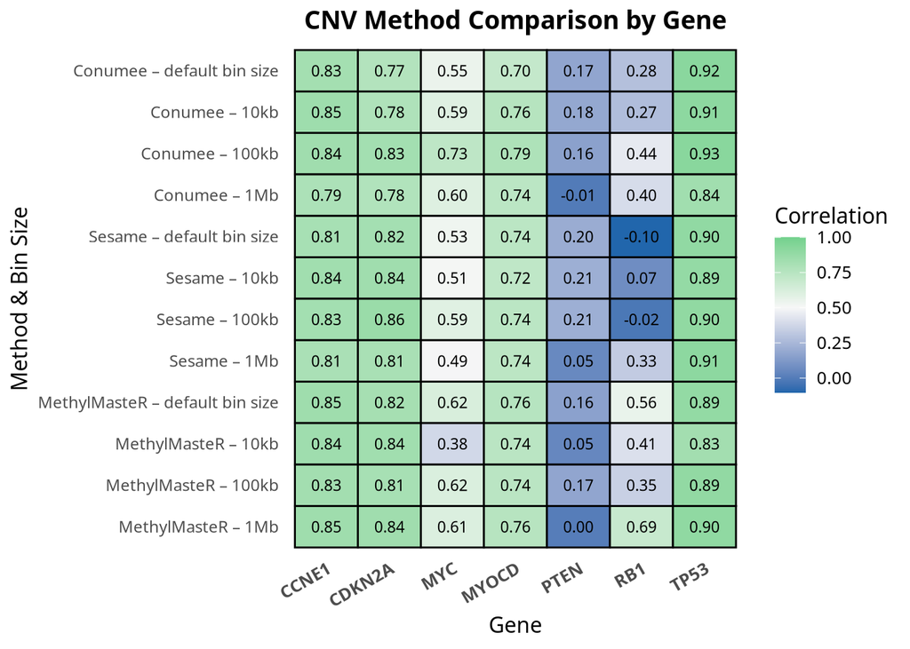

```r
# Melt to long format
df_long <- melt(output.df, id.vars = "states", variable.name = "gene",
    value.name = "correlation")

# Keep row order
df_long$states <- factor(df_long$states, levels = rev(output.df$states))

# Plot
p <- ggplot(df_long, aes(x = gene, y = states, fill = correlation)) +
    geom_tile(color = "black", linewidth = 0.5) + geom_text(aes(label = sprintf("%.2f",
    correlation)), size = 3, color = "black") + scale_fill_gradient2(low = "#2166ac",
    mid = "#f7f7f7", high = "#50C878", midpoint = 0.5, limits = c(min(df_long$correlation),
        1), name = "Correlation") + labs(title = "CNV Method Comparison by Gene",
    x = "Gene", y = "Method & Bin Size") + theme_minimal(base_size = 12) +
    theme(plot.title = element_text(hjust = 0.5, face = "bold",
        size = 14), axis.text.x = element_text(angle = 30, hjust = 1,
        face = "bold"), axis.text.y = element_text(size = 9),
        panel.grid = element_blank(), legend.position = "right")
p
```

I just ran the visualizer, as that is the meat of the code.

Finally, we need to plot the final dataset for the case.

```r
Gene <- c("MYC", "MYOCD", "CCNE1", "CDKN2A", "PTEN", "RB1", "TP53")
geneAnno(Gene = Gene, db = df)
```

```
## [1] "is here"
```

```
##    chrom loc.start   loc.end    seg.mean         type CNVStatus  Gene
## 1      8 128747765 128753680  0.01271818 Gene_MMasteR    Normal  4609
## 2      8 128747765 128753680 -0.02500000     Gene_SNP    Normal  4609
## 3      9  21967751  21994490 -0.02648182 Gene_MMasteR    Normal  1029
## 4      9  21967751  21994490 -0.04800000     Gene_SNP    Normal  1029
## 5     10  89623195  89728532 -0.34798182 Gene_MMasteR  Deletion  5728
## 6     10  89623195  89728532 -0.58100000     Gene_SNP  Deletion  5728
## 7     13  48877883  49056026 -0.32668182 Gene_MMasteR  Deletion  5925
## 8     13  48877883  49056026 -0.54700000     Gene_SNP  Deletion  5925
## 9     17   7565097   7590868 -0.07078182 Gene_MMasteR    Normal  7157
## 10    17  12569207  12670651 -0.07078182 Gene_MMasteR    Normal 93649
## 11    17   7565097   7590868  0.00000000     Gene_SNP    Normal  7157
## 12    17  12569207  12670651  0.00000000     Gene_SNP    Normal 93649
## 13    19  30302901  30315215  0.05271818 Gene_MMasteR    Normal   898
## 14    19  30302901  30315215 -0.05400000     Gene_SNP    Normal   898
```

[output cut: 25 more lines]

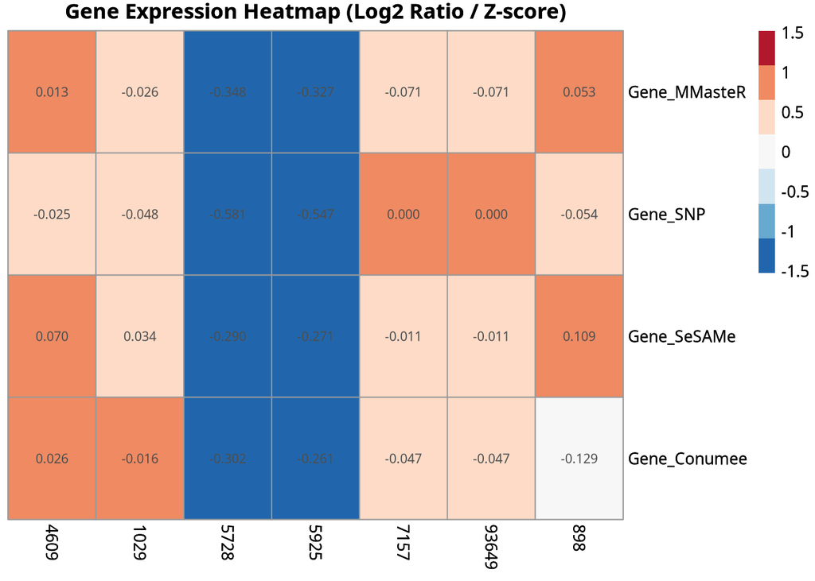

```
## # A tibble: 22 × 4
##    chrom   chr_len  chr_start     chr_mid
##    <dbl>     <dbl>      <dbl>       <dbl>
##  1     1 249220311          0  124610156.
##  2     2 243052331  249220311  370746476.
##  3     3 198172780  492272642  591359032
##  4     4 190992138  690445422  785941491
##  5     5 181369130  881437560  972122125
##  6     6 170977534 1062806690 1148295457
##  7     7 159247987 1233784224 1313408218.
##  8     8 146292734 1393032211 1466178578
##  9     9 141081716 1539324945 1609865803
## 10    10 135482374 1680406661 1748147848
## # ℹ 12 more rows
##  [1] "chr1"  "chr2"  "chr3"  "chr4"  "chr5"  "chr6"  "chr7"  "chr8"  "chr9"
```

[output cut: 488 more lines]

[figure not shown]

```
##
## [[2]]
##          seg.mean loc.start   loc.end chrom         type     CNVStatus  Gene
## 1   -0.3777818159    747994  28115000     1 MethylMaster      Deletion     0
## 2   -0.7534818159  28185000  28505000     1 MethylMaster      Deletion     0
## 3   -0.4224818159  28530000  38525000     1 MethylMaster      Deletion     0
## 4    0.1562181841  38690000 186405000     1 MethylMaster        Normal     0
## 5    0.3858181841 186560000 199570000     1 MethylMaster Amplification     0
## 6    0.1513181841 199885000 208295000     1 MethylMaster        Normal     0
## 7   -0.3127818159 208480000 248923211     1 MethylMaster      Deletion     0
## 8   -0.5230000000    754192  39046130     1          SNP      Deletion     0
## 9    0.3290000000  39053684  71837405     1          SNP Amplification     0
## 10   0.5860000000  71858457  72654730     1          SNP Amplification     0
## 11   0.3720000000  72662685  76640953     1          SNP Amplification     0
## 12  -0.0230000000  76658494  77726109     1          SNP        Normal     0
```

[output cut: 230 more lines]

It looks terribly compressed, but this is honestly just due to the limits of this RMD file. Saving it with the proper parameters make it look more like this:

[figure not shown]

A lot more elegant!

## Conclusion

That’s about it! This whole pipeline gives an elegant flow, from preprocessing the data into a common readable format, to the different forms of analysis, all the way down to the visualizations, step by step.